# Разработка модели машиного обучения с целью увеличения покупательской активности постоянных клиентов.

# Описание проекта

Персонализация предложений - это эффективный способ удержания активности постоянных клиентов и увеличения продаж в интернет-магазине. Используя данные о покупателях и алгоритмы искусственного интеллекта, вы можете создать систему персонализации, которая будет увеличивать лояльность клиентов и приносить дополнительный доход.

Интернет-магазин продаёт разные товары: для детей, для дома, мелкую бытовую технику, косметику и даже продукты. Отчёт магазина за прошлый период показал, что активность покупателей начала снижаться. Привлекать новых клиентов уже не так эффективно: о магазине и так знает большая часть целевой аудитории. Возможный выход — удерживать активность постоянных клиентов. Сделать это можно с помощью персонализированных предложений. Необходимо разработать решение, которое позволит персонализировать предложения постоянным клиентам, чтобы увеличить их покупательскую активность.

# Ход решения

1. Нужно промаркировать уровень финансовой активности постоянных покупателей. В компании принято выделять два уровня активности: «снизилась», если клиент стал покупать меньше товаров, и «прежний уровень».
2. Нужно собрать данные по клиентам по следующим группам:
   - Признаки, которые описывают коммуникацию сотрудников компании с клиентом.
   - Признаки, которые описывают продуктовое поведение покупателя. Например, какие товары покупает и как часто.
   - Признаки, которые описывают покупательское поведение клиента. Например, сколько тратил в магазине.
   - Признаки, которые описывают поведение покупателя на сайте. Например, как много страниц просматривает и сколько времени проводит на сайте.

Можно представить группы признаков в виде диаграммы Исикавы.

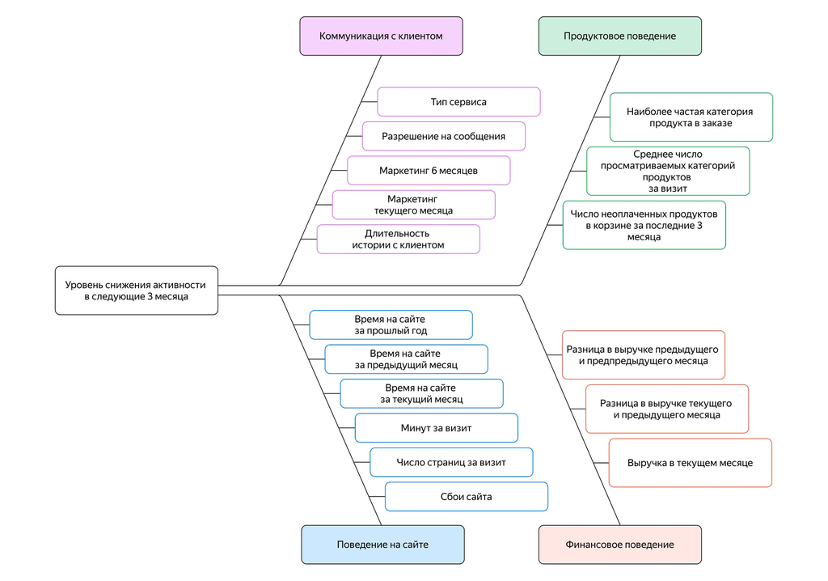

1. Нужно построить модель, которая предскажет вероятность снижения покупательской активности клиента в следующие три месяца.
2. В исследование нужно включить дополнительные данные финансового департамента о прибыльности клиента: какой доход каждый покупатель приносил компании за последние три месяца.
3. Используя данные модели и данные о прибыльности клиентов, нужно выделить сегменты покупателей и разработать для них персонализированные предложения.

# Описание данных

**Файл `market_file.csv` содержит данные о поведении покупателя на сайте, о коммуникациях с покупателем и его продуктовом поведении.**

- `id` — номер покупателя в корпоративной базе данных.
- `Покупательская активность` — рассчитанный класс покупательской активности (целевой признак): «снизилась» или «прежний уровень».
- `Тип сервиса` — уровень сервиса, например «премиум» и «стандарт».
- `Разрешить сообщать` — информация о том, можно ли присылать покупателю дополнительные предложения о товаре. Согласие на это даёт покупатель.
- `Маркет_актив_6_мес` — среднемесячное значение маркетинговых коммуникаций компании, которое приходилось на покупателя за последние 6 месяцев. Это значение показывает, какое число рассылок, звонков, показов рекламы и прочего приходилось на клиента.
- `Маркет_актив_тек_мес` — количество маркетинговых коммуникаций в текущем месяце.
- `Длительность` — значение, которое показывает, сколько дней прошло с момента регистрации покупателя на сайте.
- `Акционные_покупки` — среднемесячная доля покупок по акции от общего числа покупок за последние 6 месяцев.
- `Популярная_категория` — самая популярная категория товаров у покупателя за последние 6 месяцев.
- `Средний_просмотр_категорий_за_визит` — показывает, сколько в среднем категорий покупатель просмотрел за визит в течение последнего месяца.
- `Неоплаченные_продукты_штук_квартал` — общее число неоплаченных товаров в корзине за последние 3 месяца.
- `Ошибка_сервиса`— число сбоев, которые коснулись покупателя во время посещения сайта.
- `Страниц_за_визит` — среднее количество страниц, которые просмотрел покупатель за один визит на сайт за последние 3 месяца.

**Файл `market_money.csv` содержит данные о выручке, которую получает магазин с покупателя, то есть сколько покупатель всего потратил за период взаимодействия с сайтом.**

- `id` — номер покупателя в корпоративной базе данных.
- `Период` — название периода, во время которого зафиксирована выручка. Например, 'текущий_месяц' или 'предыдущий_месяц'.
- `Выручка` — сумма выручки за период.

**Файл `market_time.csv` содержит данные о о времени (в минутах), которое покупатель провёл на сайте в течение периода.**

- `id` — номер покупателя в корпоративной базе данных.
- `Период` — название периода, во время которого зафиксировано общее время.
- `минут` — значение времени, проведённого на сайте, в минутах.

**Файл `money.csv` содержит данные о среднемесячной прибыли покупателя за последние 3 месяца: какую прибыль получает магазин от продаж каждому покупателю.**

- `id` — номер покупателя в корпоративной базе данных.
- `Прибыль` — значение прибыли.

# Инструкция по выполнению проекта

Решать задачу нужно в два этапа:

1. Разработать модель, которая предскажет вероятность снижения покупательской активности.
2. Выделить сегмент покупателей, проанализировать его и предложить, как увеличить его покупательскую активность.

# План работы

**Шаг 1. Загрузка данных**

1. Загрузить данные. Файлы `market_file.csv`, `market_money.csv`, `market_time.csv`, `money.csv` доступны по ссылкам в описании данных или через пути к ним:
- `/datasets/market_file.csv`
- `/datasets/market_money.csv`
- `/datasets/market_time.csv`
- `/datasets/money.csv`

**Шаг 2. Предобработка данных**

Провести необходимую предобработку данных.

**Шаг 3. Исследовательский анализ данных**

Провести исследовательский анализ данных из каждой таблицы. Отобрать клиентов с покупательской активностью не менее трёх месяцев, то есть таких, которые что-либо покупали в этот период. Оформить выводы по результатам шага.

**Шаг 4. Объединение таблиц**

1. Объединить таблицы `market_file.csv`, `market_money.csv`, `market_time.csv`.
2. Учесть, что данные о выручке и времени на сайте находятся в одном столбце для всех периодов. В итоговой таблице сделать отдельный столбец для каждого периода.

**Шаг 5. Корреляционный анализ**

Провести корреляционный анализ признаков в количественной шкале в итоговой таблице для моделирования. Сделать выводы о мультиколлинеарности и при необходимости устранить её.

**Шаг 6. Использование пайплайнов**

1. Во время подготовки данных использовать `ColumnTransformer`. Количественные и категориальные признаки обработать в пайплайне раздельно. Для кодирования категориальных признаков использовать как минимум два кодировщика, для масштабирования количественных — как минимум два скейлера.
2. Обучить четыре модели: `KNeighborsClassifier()`, `DecisionTreeClassifier()`, `LogisticRegression()` и `SVC()`. Для каждой из них подобрать как минимум один гиперпараметр. Выбрать подходящую для задачи метрику, аргументировать свой выбор. Использовать эту метрику при подборе гиперпараметров.
3. Выбрать лучшую модель, используя заданную метрику. Для этого применить одну из стратегий:
   - использовать пайплайны и инструменты подбора гиперпараметров для каждой модели отдельно, чтобы выбрать лучшую модель;
   - использовать один общий пайплайн для всех моделей и инструмент подбора гиперпараметров, который вернёт вам лучшую модель.

**Шаг 7. Анализ важности признаков**

1. Оценить важность признаков для лучшей модели и построть график важности с помощью метода SHAP.
2. Сделать выводы о значимости признаков:
   - какие признаки мало значимы для модели;
   - какие признаки сильнее всего влияют на целевой признак;
   - как можно использовать эти наблюдения при моделировании и принятии бизнес-решений.

**Шаг 8. Сегментация покупателей**

1. Выполнить сегментацию покупателей. Использовать результаты моделирования и данные о прибыльности покупателей.
2. Выбрать группу покупателей и предложить, как увеличить её покупательскую активность:
   - Провести графическое и аналитическое исследование группы покупателей.
   - Сделать предложения по работе с сегментом для увеличения покупательской активности.
3. Сделать выводы о сегментах:
   - какой сегмент взяли для дополнительного исследования,
   - какие предложения сделали и почему.

**Шаг 9. Общий вывод**

Сделать общий вывод:

- описать задачу;
- описать исходные данные и проведённую предобработку;
- написать, что сделали для поиска лучшей модели;
- указать лучшую модель;
- добавить выводы и дополнительные предложения для выбранного сегмента покупателей.

## Загрузка данных

На данном шаге нам необходимо загрузить необходимые библиотеки, загрузить и ознакомится с данными.

### Импортируем необходимые библиотеки

```python
!pip install -q -U scikit-learn
!pip install -q shap
import pandas as pd
import numpy as np
import seaborn as sns
import matplotlib.pyplot as plt
import scipy.stats as st
import sklearn
import shap

import warnings
warnings.filterwarnings('ignore')

# Задаем константы
RANDOM_STATE = 42
TEST_SIZE = 0.25

# импортируем функцию для разделения данных
from sklearn.model_selection import train_test_split

# импортируем класс RandomizedSearchCV
from sklearn.model_selection import RandomizedSearchCV

# загружаем нужные модели
from sklearn.linear_model import LogisticRegression
from sklearn.neighbors import KNeighborsClassifier
from sklearn.tree import DecisionTreeClassifier
from sklearn.svm import SVC

# загружаем классы для подготовки данных
from sklearn.preprocessing import (
    OneHotEncoder,
    OrdinalEncoder,
    StandardScaler,
    MinMaxScaler,
    RobustScaler)

# загружаем необходимые инструменты
from sklearn.pipeline import Pipeline
from sklearn.compose import ColumnTransformer

# загружаем класс для работы с пропусками
from sklearn.impute import SimpleImputer

# загружаем инструмент для автоподбора гиперпараметров
from sklearn.model_selection import GridSearchCV

# импортируем функции для работы с метриками
from sklearn.metrics import accuracy_score, precision_score, recall_score, confusion_matrix, roc_auc_score
```

### Загрузим данные в датафреймы pandas.

```python
try:
    market_file = pd.read_csv('market_file.csv', decimal=",")
    market_money = pd.read_csv('market_money.csv', delimiter=",", decimal=",")
    market_time = pd.read_csv('market_time.csv', delimiter=",", decimal=",")
    money = pd.read_csv('money.csv', delimiter=";", decimal=",")
except:
    market_file = pd.read_csv('https://code.s3.yandex.net/datasets/market_file.csv', sep = ',', encoding='utf8', decimal=',')
    market_money = pd.read_csv('https://code.s3.yandex.net/datasets/market_money.csv', sep = ',', encoding='utf8', decimal=',')
    market_time = pd.read_csv('https://code.s3.yandex.net/datasets/market_time.csv', sep = ',', encoding='utf8', decimal=',')
    money = pd.read_csv('https://code.s3.yandex.net/datasets/money.csv', sep = ';', encoding='utf8', decimal=',')
```

```python
market_file.head(3)
```

|  | id | Покупательская активность | Тип сервиса | Разрешить сообщать | Маркет_актив_6_мес | Маркет_актив_тек_мес | Длительность | Акционные_покупки | Популярная_категория | Средний_просмотр_категорий_за_визит | Неоплаченные_продукты_штук_квартал | Ошибка_сервиса | Страниц_за_визит |
| --- | --- | --- | --- | --- | --- | --- | --- | --- | --- | --- | --- | --- | --- |
| 0 | 215348 | Снизилась | премиум | да | 3.4 | 5 | 121 | 0.0 | Товары для детей | 6 | 2 | 1 | 5 |
| 1 | 215349 | Снизилась | премиум | да | 4.4 | 4 | 819 | 0.75 | Товары для детей | 4 | 4 | 2 | 5 |
| 2 | 215350 | Снизилась | стандартт | нет | 4.9 | 3 | 539 | 0.14 | Домашний текстиль | 5 | 2 | 1 | 5 |

```python
market_file.info()
```

```
<class 'pandas.core.frame.DataFrame'>
RangeIndex: 1300 entries, 0 to 1299
Data columns (total 13 columns):
 #   Column                               Non-Null Count  Dtype
---  ------                               --------------  -----
 0   id                                   1300 non-null   int64
 1   Покупательская активность            1300 non-null   object
 2   Тип сервиса                          1300 non-null   object
 3   Разрешить сообщать                   1300 non-null   object
 4   Маркет_актив_6_мес                   1300 non-null   object
 5   Маркет_актив_тек_мес                 1300 non-null   int64
 6   Длительность                         1300 non-null   int64
 7   Акционные_покупки                    1300 non-null   object
 8   Популярная_категория                 1300 non-null   object
 9   Средний_просмотр_категорий_за_визит  1300 non-null   int64
 10  Неоплаченные_продукты_штук_квартал   1300 non-null   int64
 11  Ошибка_сервиса                       1300 non-null   int64
 12  Страниц_за_визит                     1300 non-null   int64
dtypes: int64(7), object(6)
memory usage: 132.2+ KB
```

```python
market_money.head(3)
```

|  | id | Период | Выручка |
| --- | --- | --- | --- |
| 0 | 215348 | препредыдущий_месяц | 0.0 |
| 1 | 215348 | текущий_месяц | 3293.1 |
| 2 | 215348 | предыдущий_месяц | 0.0 |

```python
market_money.info()
```

```
<class 'pandas.core.frame.DataFrame'>
RangeIndex: 3900 entries, 0 to 3899
Data columns (total 3 columns):
 #   Column   Non-Null Count  Dtype
---  ------   --------------  -----
 0   id       3900 non-null   int64
 1   Период   3900 non-null   object
 2   Выручка  3900 non-null   object
dtypes: int64(1), object(2)
memory usage: 91.5+ KB
```

```python
market_time.head(3)
```

|  | id | Период | минут |
| --- | --- | --- | --- |
| 0 | 215348 | текущий_месяц | 14 |
| 1 | 215348 | предыдцщий_месяц | 13 |
| 2 | 215349 | текущий_месяц | 10 |

```python
market_time.info()
```

```
<class 'pandas.core.frame.DataFrame'>
RangeIndex: 2600 entries, 0 to 2599
Data columns (total 3 columns):
 #   Column  Non-Null Count  Dtype
---  ------  --------------  -----
 0   id      2600 non-null   int64
 1   Период  2600 non-null   object
 2   минут   2600 non-null   int64
dtypes: int64(2), object(1)
memory usage: 61.1+ KB
```

```python
money.head(3)
```

|  | id | Прибыль |
| --- | --- | --- |
| 0 | 215348 | 0.98 |
| 1 | 215349 | 4.16 |
| 2 | 215350 | 3.13 |

```python
money.info()
```

```
<class 'pandas.core.frame.DataFrame'>
RangeIndex: 1300 entries, 0 to 1299
Data columns (total 2 columns):
 #   Column   Non-Null Count  Dtype
---  ------   --------------  -----
 0   id       1300 non-null   int64
 1   Прибыль  1300 non-null   float64
dtypes: float64(1), int64(1)
memory usage: 20.4 KB
```

**Выводы по загрузке и изучению данных:**

- По первичной информации замечены неправильные типы данных, ошибки в данных, а также нестандартное оформление названия столбцов.
- Данные в таблицах соответствуют описанию.

## Предобработка данных

На данном шаге проверим данные на наличие пропусков и дубликатов. Узнаем, корректны ли типы данных у каждого признака. При необходимости устраним все проблемы с данными.

### Приведем названия столбцов к стандартам оформления данных

```python
market_file = market_file.rename(columns={'Покупательская активность':'Покупательская_активность',
                                         'Тип сервиса':'Тип_сервиса',
                                         'Разрешить сообщать':'Разрешить_сообщать'})
```

```python
market_time = market_time.rename(columns={'минут':'Минут'})
```

### Проверим данные на наличие неявных дубликатов и ошибок

Проверим данные датасета `market_file` на наличие неявных дубликатов или ошибок в данных

```python
market_file['Покупательская_активность'].unique()
```

```
array(['Снизилась', 'Прежний уровень'], dtype=object)
```

```python
market_file['Тип_сервиса'].unique()
```

```
array(['премиум', 'стандартт', 'стандарт'], dtype=object)
```

```python
market_file['Разрешить_сообщать'].unique()
```

```
array(['да', 'нет'], dtype=object)
```

```python
market_file['Популярная_категория'].unique()
```

```
array(['Товары для детей', 'Домашний текстиль', 'Косметика и аксесуары',
       'Техника для красоты и здоровья', 'Кухонная посуда',
       'Мелкая бытовая техника и электроника'], dtype=object)
```

```python
market_file['Маркет_актив_тек_мес'].unique()
```

```
array([5, 4, 3], dtype=int64)
```

```python
market_file['Средний_просмотр_категорий_за_визит'].unique()
```

```
array([6, 4, 5, 3, 2, 1], dtype=int64)
```

```python
market_file['Ошибка_сервиса'].unique()
```

```
array([1, 2, 6, 3, 7, 9, 4, 5, 8, 0], dtype=int64)
```

```python
market_file['Страниц_за_визит'].unique()
```

```
array([ 5,  4,  2,  3,  7,  1,  6,  8,  9, 14, 11, 15, 16, 10, 17, 13, 12,
       18, 19, 20], dtype=int64)
```

```python
market_file.loc[market_file['Тип_сервиса'] == 'стандартт', 'Тип_сервиса'] = 'стандарт'
```

Проверим данные датасета `market_money` на наличие неявных дубликатов или ошибок в данных

```python
market_money['Период'].unique()
```

```
array(['препредыдущий_месяц', 'текущий_месяц', 'предыдущий_месяц'],
      dtype=object)
```

Проверим данные датасета `market_time` на наличие неявных дубликатов или ошибок в данных

```python
market_time['Период'].unique()
```

```
array(['текущий_месяц', 'предыдцщий_месяц'], dtype=object)
```

```python
market_time.loc[market_time['Период'] == 'предыдцщий_месяц', 'Период'] = 'предыдущий_месяц'
```

### Проверим данные на наличие явных дубликатов

```python
print('Количество явных дубликатов в датасете market_file:', market_file.duplicated().sum())
print('Количество явных дубликатов в датасете market_money:', market_money.duplicated().sum())
print('Количество явных дубликатов в датасете market_time:', market_time.duplicated().sum())
print('Количество явных дубликатов в датасете money:', money.duplicated().sum())
```

```
Количество явных дубликатов в датасете market_file: 0
Количество явных дубликатов в датасете market_money: 0
Количество явных дубликатов в датасете market_time: 0
Количество явных дубликатов в датасете money: 0
```

```python
market_money = market_money.drop_duplicates()
```

### Преобразуем данные в нужные типы

```python
market_file['Маркет_актив_6_мес'] = market_file['Маркет_актив_6_мес'].astype('float64')
market_file['Акционные_покупки'] = market_file['Акционные_покупки'].astype('float64')
```

```python
market_money['Выручка'] = market_money['Выручка'].astype('float64')
```

### Выводы по предобработке данных

По итогам предобработке данных:

- привели названия столбцов к стандартам оформления данных;
- проверили пропуски в данных;
- проверили данные на явные и неявные пропуски и избавлись от них;
- преобразовали данные к правильному типу. Данные с плавающей запятой типа object были заменены на данные с плавающей точкой типа float64.

## Исследовательский анализ данных

На данном шаге необходимо провести исследовательский анализ данных по каждому датасету. Отобрать клиентов с покупательской активностью не менее трёх месяцев, то есть таких, которые что-либо покупали в этот период.

### Проведем статистический анализ признаков

```python
market_file.describe()
```

|  | id | Маркет_актив_6_мес | Маркет_актив_тек_мес | Длительность | Акционные_покупки | Средний_просмотр_категорий_за_визит | Неоплаченные_продукты_штук_квартал | Ошибка_сервиса | Страниц_за_визит |
| --- | --- | --- | --- | --- | --- | --- | --- | --- | --- |
| count | 1300.000000 | 1300.000000 | 1300.000000 | 1300.000000 | 1300.000000 | 1300.00000 | 1300.000000 | 1300.000000 | 1300.000000 |
| mean | 215997.500000 | 4.253769 | 4.011538 | 601.898462 | 0.319808 | 3.27000 | 2.840000 | 4.185385 | 8.176923 |
| std | 375.421985 | 1.014814 | 0.696868 | 249.856289 | 0.249843 | 1.35535 | 1.971451 | 1.955298 | 3.978126 |
| min | 215348.000000 | 0.900000 | 3.000000 | 110.000000 | 0.000000 | 1.00000 | 0.000000 | 0.000000 | 1.000000 |
| 25% | 215672.750000 | 3.700000 | 4.000000 | 405.500000 | 0.170000 | 2.00000 | 1.000000 | 3.000000 | 5.000000 |
| 50% | 215997.500000 | 4.200000 | 4.000000 | 606.000000 | 0.240000 | 3.00000 | 3.000000 | 4.000000 | 8.000000 |
| 75% | 216322.250000 | 4.900000 | 4.000000 | 806.000000 | 0.300000 | 4.00000 | 4.000000 | 6.000000 | 11.000000 |
| max | 216647.000000 | 6.600000 | 5.000000 | 1079.000000 | 0.990000 | 6.00000 | 10.000000 | 9.000000 | 20.000000 |

- Среднее среднемесячного значения маркетинговых коммуникаций компании, которое приходилось на покупателя за последние 6 месяцев составляет 4, максимальное значение 6.6.
- Среднее количество маркетинговых коммуникаций в текущем месяце составляет 4, максимальное значение 5.
- Среднее количество дней с момента регистрации покупателя на сайте составляет 602, максимальное 1079.
- Среднее значение среднемесячной доли покупок по акции от общего числа покупок за последние 6 месяцев составляет 0.32, максимальное значение 0.99.
- Среднее количество категорий, которые покупатель просмотрел за визит в течение последнего месяца составляет 3, максимальное 6.
- Среднее число неоплаченных товаров в корзине за последние 3 месяца составляет 3, максимальное 10.
- Среднее число сбоев, которые коснулись покупателя во время посещения сайта составляет 4, максимальное 9.
- Среднее значение среднего количества страниц, которые просмотрел покупатель за один визит на сайт за последние 3 месяца составляет 8, максимальное 20.

```python
market_money.describe()
```

|  | id | Выручка |
| --- | --- | --- |
| count | 3900.000000 | 3900.000000 |
| mean | 215997.500000 | 5025.696051 |
| std | 375.325686 | 1777.704104 |
| min | 215348.000000 | 0.000000 |
| 25% | 215672.750000 | 4590.150000 |
| 50% | 215997.500000 | 4957.500000 |
| 75% | 216322.250000 | 5363.000000 |
| max | 216647.000000 | 106862.200000 |

```python
market_time.describe()
```

|  | id | Минут |
| --- | --- | --- |
| count | 2600.000000 | 2600.000000 |
| mean | 215997.500000 | 13.336154 |
| std | 375.349754 | 4.080198 |
| min | 215348.000000 | 4.000000 |
| 25% | 215672.750000 | 10.000000 |
| 50% | 215997.500000 | 13.000000 |
| 75% | 216322.250000 | 16.000000 |
| max | 216647.000000 | 23.000000 |

- Среднее значение времени, проведённого на сайте, в минутах составляет 13.34, максимальное 23.

```python
money.describe()
```

|  | id | Прибыль |
| --- | --- | --- |
| count | 1300.000000 | 1300.000000 |
| mean | 215997.500000 | 3.996631 |
| std | 375.421985 | 1.013722 |
| min | 215348.000000 | 0.860000 |
| 25% | 215672.750000 | 3.300000 |
| 50% | 215997.500000 | 4.045000 |
| 75% | 216322.250000 | 4.670000 |
| max | 216647.000000 | 7.430000 |

- Среднее значение прибыли составялет 4.0, максимальное 7.43.

### Построим графики для каждого признака датасета `market_file.csv`

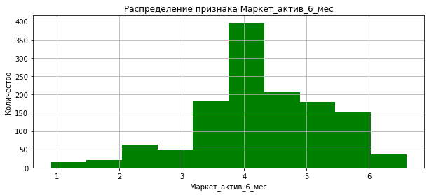

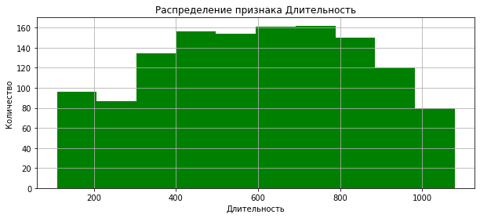

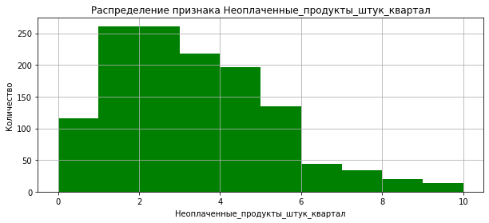

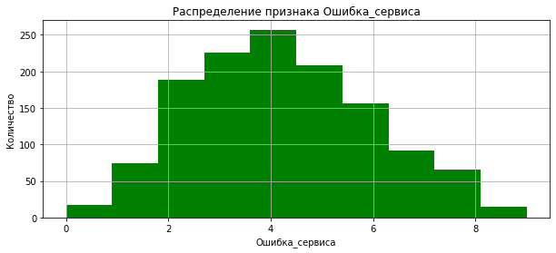

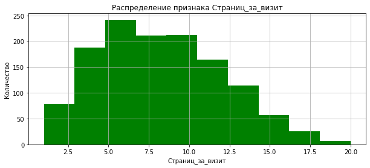

```python
for i in market_file[['Маркет_актив_6_мес',
                      'Длительность',
                      'Неоплаченные_продукты_штук_квартал',
                      'Ошибка_сервиса',
                      'Страниц_за_визит']]:
    market_file[i].plot(kind='hist', grid=True, title= f'Распределение признака {i}', bins=10, color='green', figsize=(10,4));
    plt.xlabel(i)
    plt.ylabel('Количество')
    plt.show()
```

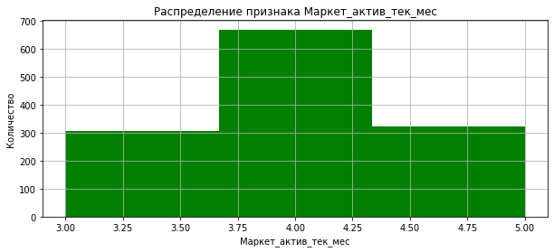

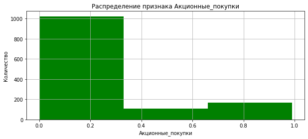

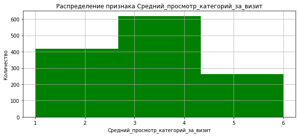

```python
for i in market_file[['Маркет_актив_тек_мес',
                      'Акционные_покупки',
                      'Средний_просмотр_категорий_за_визит']]:
    market_file[i].plot(kind='hist', grid=True, title= f'Распределение признака {i}', bins=3, color='green', figsize=(10,4));
    plt.xlabel(i)
    plt.ylabel('Количество')
    plt.show()
```

Также построим график "ящики с усами", который покажет выбросы и основные статистики данных (квартили)

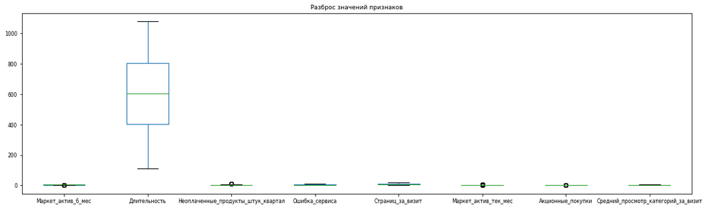

```python
plt.rcParams.update({'font.size': 7.5})
market_file[['Маркет_актив_6_мес',
          'Длительность',
          'Неоплаченные_продукты_штук_квартал',
          'Ошибка_сервиса',
          'Страниц_за_визит',
          'Маркет_актив_тек_мес',
          'Акционные_покупки',
          'Средний_просмотр_категорий_за_визит']].plot(kind='box', figsize=(18, 5))
plt.title('Разброс значений признаков')
plt.show();
```

Далее построим графики признаков в масштабированном формате, чтобы крупнее отразить боксплоты, вантили и медианы.

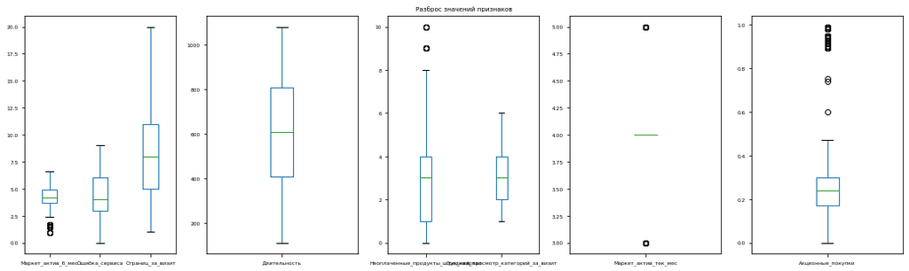

```python
plt.rcParams.update({'font.size': 6})
fig, axes = plt.subplots(nrows=1, ncols=5, figsize=(18,5))
axes[2].set_title('Разброс значений признаков')
market_file[['Маркет_актив_6_мес', 'Ошибка_сервиса', 'Страниц_за_визит',]].plot(kind='box', ax=axes[0])
market_file['Длительность'].plot(kind='box', ax=axes[1])
market_file[['Неоплаченные_продукты_штук_квартал', 'Средний_просмотр_категорий_за_визит']].plot(kind='box', ax=axes[2])
market_file['Маркет_актив_тек_мес'].plot(kind='box', ax=axes[3])
market_file['Акционные_покупки'].plot(kind='box', ax=axes[4])
plt.show();
```

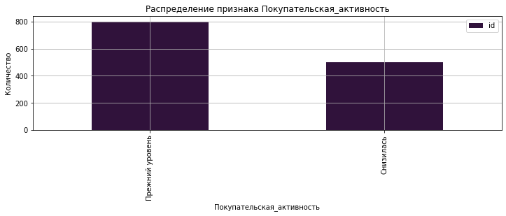

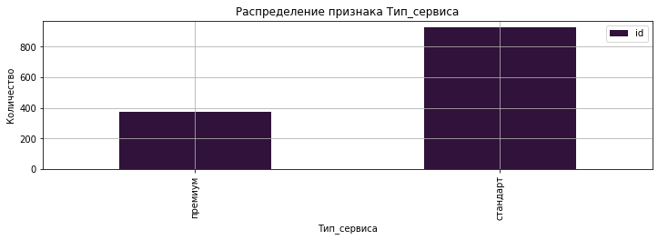

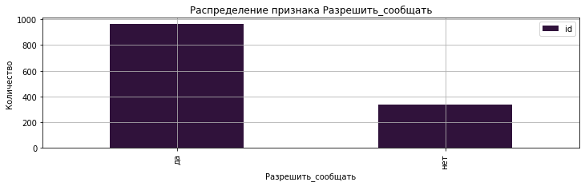

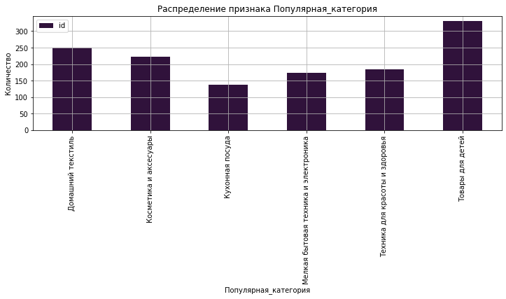

```python
plt.rcParams.update({'font.size': 10})
for i in market_file[['Покупательская_активность', 'Тип_сервиса', 'Разрешить_сообщать', 'Популярная_категория']]:
    market_file.pivot_table(index=i,
                         values='id',
                         aggfunc='count').plot(kind='bar',
                                               grid=True,
                                               title= f'Распределение признака {i}',
                                               colormap="turbo", figsize=(12,3));
    plt.ylabel('Количество')
    plt.show()
```

**Выводы по графикам качественных признаков:**

- По распределению признака 'Покупательская_активность' можно сказать, что чаще всего встречается "прежний уровень".
- По распределению признака 'Тип_сервиса', можно сказать, что чаще всего встречается "стандарт".
- По распределению признака 'Разрешить_сообщать', можно сказать, что чаще всего встречается "да".
- По распределению признака 'Популярная_категория', можно сказать, что чаще всего встречается "Товары для детей".

### Построим графики для каждого признака датасета `market_money.csv`

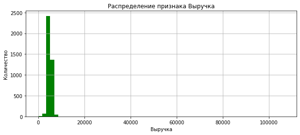

```python
market_money['Выручка'].plot(kind='hist',
                             grid=True,
                             title='Распределение признака Выручка',
                             bins=62,
                             color='green',
                             figsize=(10,4));
plt.xlabel('Выручка')
plt.ylabel('Количество')
plt.show()
```

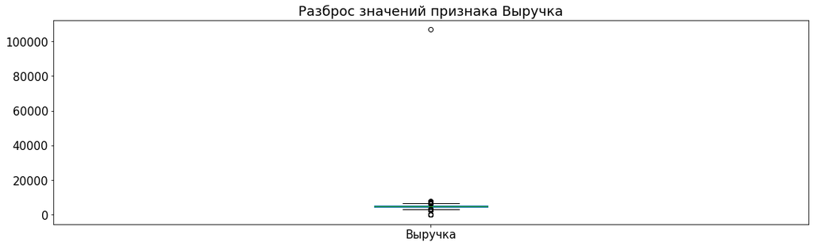

```python
plt.rcParams.update({'font.size': 15})
market_money['Выручка'].plot(kind='box', figsize=(18, 5))
plt.title('Разброс значений признака Выручка')
plt.show();
```

**Выводы по графику количественного признака 'Выручка':**

- По графику "ящик с усами" отмечается сильный выброс в большую сторону.
- По распределению признака, можно сказать, что наиболее часто встречатеся выручка в диапазоне 5000.

Избавимся от выброса в признаке выручка.

По графику "ящик с усами", можно утверждать, что выручка более 10000 признается выбросами. Избавимся от них.

```python
market_money = market_money.query('Выручка<10000 and Выручка!=0')
```

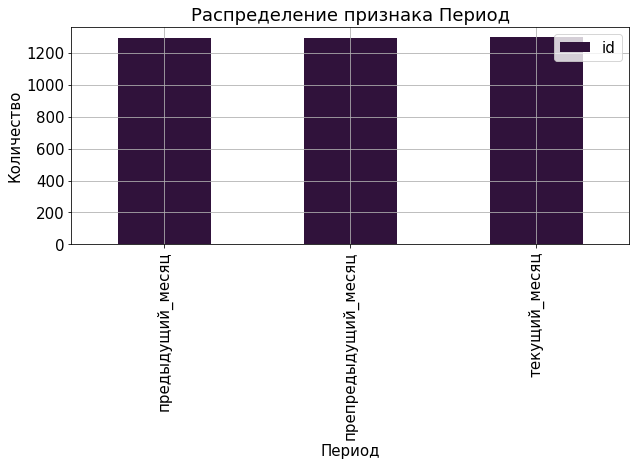

```python
market_money.pivot_table(index='Период', values='id', aggfunc='count').plot(kind='bar',
                                               grid=True,
                                               title= 'Распределение признака Период',
                                               colormap="turbo", figsize=(10,4));
plt.ylabel('Количество')
plt.show()
```

### Построим графики для каждого признака датасета `market_time.csv`

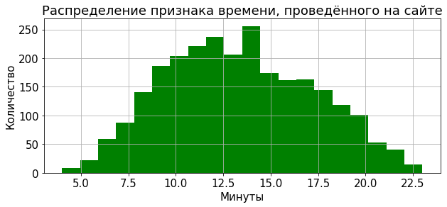

```python
market_time['Минут'].plot(kind='hist',
                             grid=True,
                             title='Распределение признака времени, проведённого на сайте',
                             bins=20,
                             color='green',
                             figsize=(10,4));
plt.xlabel('Минуты')
plt.ylabel('Количество')
plt.show()
```

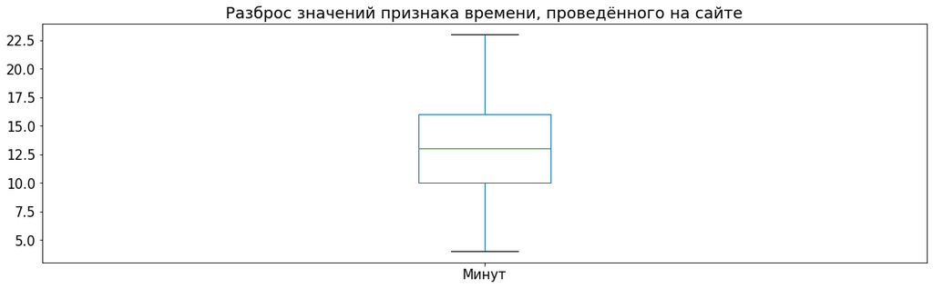

```python
plt.rcParams.update({'font.size': 15})
market_time['Минут'].plot(kind='box', figsize=(18, 5))
plt.title('Разброс значений признака времени, проведённого на сайте')
plt.show();
```

**Выводы по графику количественного признака - времени, проведённого на сайте:**

- По распределению признака, можно сказать, что наиболее часто встречается время 13,5 минут.
- Распределение признака времени, проведённого на сайте близко к нормальному. Это подтверждается графиком "ящик с усами", на котором видно, что максимальные и минимальные значения распределены с равномерной удаленностью.

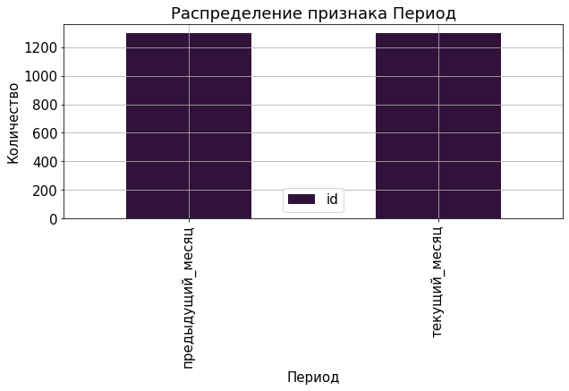

```python
market_time.pivot_table(index='Период', values='id', aggfunc='count').plot(kind='bar',
                                               grid=True,
                                               title= 'Распределение признака Период',
                                               colormap="turbo", figsize=(10,4));
plt.ylabel('Количество')
plt.show()
```

**Выводы по графику качественного признака:**

- По распределению признака 'Период' можно сказать, что две категории распределены равномерно по количеству.

### Построим графики для каждого признака датасета `money.csv`

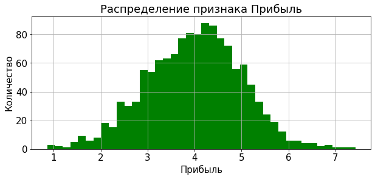

```python
money['Прибыль'].plot(kind='hist',
                             grid=True,
                             title='Распределение признака Прибыль',
                             bins=40,
                             color='green',
                             figsize=(10,4));
plt.xlabel('Прибыль')
plt.ylabel('Количество')
plt.show()
```

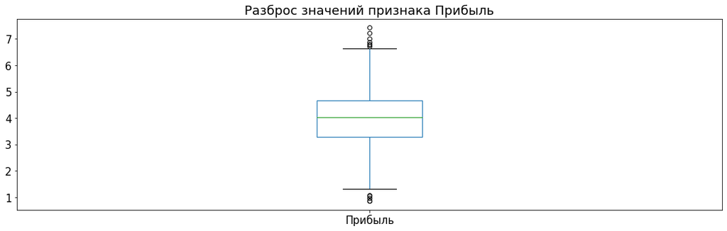

```python
plt.rcParams.update({'font.size': 15})
money['Прибыль'].plot(kind='box', figsize=(18, 5))
plt.title('Разброс значений признака Прибыль')
plt.show();
```

**Выводы по графику количественного признака - Прибыль:**

- По распределению признака, можно сказать, что наиболее часто прибыль встречатеся в диапазоне 4.2-4.4.
- Распределение признака прибыль близко к нормальному. Это подтверждается графиком "ящик с усами", на котором видно, что максимальные и минимальные значения распределены с равномерной удаленностью.
- По графику "ящик с усами" отмечаются выбросы в обе стороны.

### Вывод по исследовательскому анализу данных

**По статистическому анализу признаков датасета `market_file`, можно сказать следующее:**

- Среднее среднемесячного значения маркетинговых коммуникаций компании, которое приходилось на покупателя за последние 6 месяцев составляет 4, максимальное значение 6.6.
- Среднее количество маркетинговых коммуникаций в текущем месяце составляет 4, максимальное значение 5.
- Среднее количество дней с момента регистрации покупателя на сайте составляет 602, максимальное 1079.
- Среднее значение среднемесячной доли покупок по акции от общего числа покупок за последние 6 месяцев составляет 0.32, максимальное значение 0.99.
- Среднее количество категорий, которые покупатель просмотрел за визит в течение последнего месяца составляет 3, максимальное 6.
- Среднее число неоплаченных товаров в корзине за последние 3 месяца составляет 3, максимальное 10.
- Среднее число сбоев, которые коснулись покупателя во время посещения сайта составляет 4, максимальное 9.
- Среднее значение среднего количества страниц, которые просмотрел покупатель за один визит на сайт за последние 3 месяца составляет 8, максимальное 20.

**По статистическому анализу признаков датасета `market_time`, можно сказать следующее:**

- Среднее значение времени, проведённого на сайте, в минутах составляет 13.34, максимальное 23.

**По статистическому анализу признаков датасета `money`, можно сказать следующее:**

- Среднее значение прибыли составялет 4.0, максимальное 7.43.

**По графикам, построенным по датасету `market_time`, можно сделать следующие выводы:**

- По распределению признака, можно сказать, что наиболее часто встречается время 13,5 минут.
- Распределение признака времени, проведённого на сайте близко к нормальному. Это подтверждается графиком "ящик с усами", на котором видно, что максимальные и минимальные значения распределены с равномерной удаленностью.
- По распределению признака 'Период' можно сказать, что две категории распределены равномерно по количеству.

**По графикам, построенным по датасету `money`, можно сделать следующие выводы:**

- По распределению признака, можно сказать, что наиболее часто прибыль встречатеся в диапазоне 4.2-4.4.
- Распределение признака прибыль близко к нормальному. Это подтверждается графиком "ящик с усами", на котором видно, что максимальные и минимальные значения распределены с равномерной удаленностью.
- По графику "ящик с усами" отмечаются выбросы в обе стороны.

## Объединение таблиц

На данном шаге необходимо объединить датасеты `market_file`, `market_money`, `market_time`. Необходимо учесть, что данные о выручке и времени на сайте находятся в одном столбце для всех периодов. В итоговой таблице необходимо сделать отдельный столбец для каждого периода.

### Объединим таблицы

Разделим датасеты `market_money`, `market_time` по периодам и объединим их по разделенным периодам.

```python
market_money_tec = market_money.query('Период=="текущий_месяц"')
market_money_pred = market_money.query('Период=="предыдущий_месяц"')
market_money_prepred = market_money.query('Период=="препредыдущий_месяц"')
```

```python
market_time_tec = market_time.query('Период=="текущий_месяц"')
market_time_pred = market_time.query('Период=="предыдущий_месяц"')
```

```python
tec = pd.merge(market_money_tec, market_time_tec, how='left', on=['id', 'Период'])
tec = tec.rename(columns={'Выручка':'Выручка_текущий_месяц','Минут':'Минут_текущий_месяц'})
tec.pop('Период')
tec.head(3)
```

|  | id | Выручка_текущий_месяц | Минут_текущий_месяц |
| --- | --- | --- | --- |
| 0 | 215348 | 3293.1 | 14 |
| 1 | 215349 | 4971.6 | 10 |
| 2 | 215350 | 5058.4 | 13 |

```python
prepred = market_money_pred.merge(market_money_prepred, on=['id'])
prepred = prepred.dropna()
prepred = prepred.rename(columns={'Выручка_x':'Выручка_предыдущий_месяц','Выручка_y':'Выручка_препредыдущий_месяц'})
prepred.pop('Период_x')
prepred.pop('Период_y')
prepred.head(3)
```

|  | id | Выручка_предыдущий_месяц | Выручка_препредыдущий_месяц |
| --- | --- | --- | --- |
| 0 | 215349 | 5216.0 | 4472.0 |
| 1 | 215350 | 5457.5 | 4826.0 |
| 2 | 215351 | 6158.0 | 4793.0 |

```python
pred = prepred.merge(market_time_pred, on=['id'])
pred = pred.dropna()
pred = pred.rename(columns={'Минут':'Минут_предыдущий_месяц'})
pred.pop('Период')
pred.head()
```

|  | id | Выручка_предыдущий_месяц | Выручка_препредыдущий_месяц | Минут_предыдущий_месяц |
| --- | --- | --- | --- | --- |
| 0 | 215349 | 5216.0 | 4472.0 | 12 |
| 1 | 215350 | 5457.5 | 4826.0 | 8 |
| 2 | 215351 | 6158.0 | 4793.0 | 11 |
| 3 | 215352 | 5807.5 | 4594.0 | 8 |
| 4 | 215353 | 4738.5 | 5124.0 | 10 |

Объединим `market_file` с получившимися разделенными по периодам датасетами.

```python
market = market_file.merge(tec, how='left', on=['id'])
```

```python
market = market.merge(pred, how='left', on=['id'])
```

```python
market.head(3)
```

|  | id | Покупательская_активность | Тип_сервиса | Разрешить_сообщать | Маркет_актив_6_мес | Маркет_актив_тек_мес | Длительность | Акционные_покупки | Популярная_категория | Средний_просмотр_категорий_за_визит | Неоплаченные_продукты_штук_квартал | Ошибка_сервиса | Страниц_за_визит | Выручка_текущий_месяц | Минут_текущий_месяц | Выручка_предыдущий_месяц | Выручка_препредыдущий_месяц | Минут_предыдущий_месяц |
| --- | --- | --- | --- | --- | --- | --- | --- | --- | --- | --- | --- | --- | --- | --- | --- | --- | --- | --- |
| 0 | 215348 | Снизилась | премиум | да | 3.4 | 5 | 121 | 0.00 | Товары для детей | 6 | 2 | 1 | 5 | 3293.1 | 14.0 | NaN | NaN | NaN |
| 1 | 215349 | Снизилась | премиум | да | 4.4 | 4 | 819 | 0.75 | Товары для детей | 4 | 4 | 2 | 5 | 4971.6 | 10.0 | 5216.0 | 4472.0 | 12.0 |
| 2 | 215350 | Снизилась | стандарт | нет | 4.9 | 3 | 539 | 0.14 | Домашний текстиль | 5 | 2 | 1 | 5 | 5058.4 | 13.0 | 5457.5 | 4826.0 | 8.0 |

```python
print(f'Размерность датасета до отбора клиентов: {market.shape}')
```

```
Размерность датасета до отбора клиентов: (1300, 18)
```

### Отберем клиентов с покупательской активностью не менее трёх месяцев

Для того, чтобы отобрать клиентов с покупательской активностью не менее трёх месяцев, будем использовать выручку за препредыдущий месяц, предыдущий месяц и текущий месяц уже в объединенном датасете `маркет`. Необходимо избавиться от пустых значениях в данных столбцах. Нули удалены ранее.

```python
market = market.dropna()
```

```python
print(f'Размерность датасета после отбора клиентов: {market.shape}')
```

```
Размерность датасета после отбора клиентов: (1296, 18)
```

Получилось 1296 покупателя из 1300 имеют покупательскую активность не менее трех месяцев.

### Вывод по объединению таблиц и отбору покупателей:

- Создан итоговой датасет с отдельными столбцами для выручки и минут для каждого периода (текущий месяц и предыдущий месяц).
- Отобраны 1296 покупатеей, которые имеют покупательскую активность не менее трех месяцев.

## Корреляционный анализ

На данном этапе необходимо провести корреляционный анализ признаков в количественной шкале в итоговой таблице для моделирования. Сделаем выводы о мультиколлинеарности и при необходимости устраним её.

### Изучим взаимосвязь между признаками

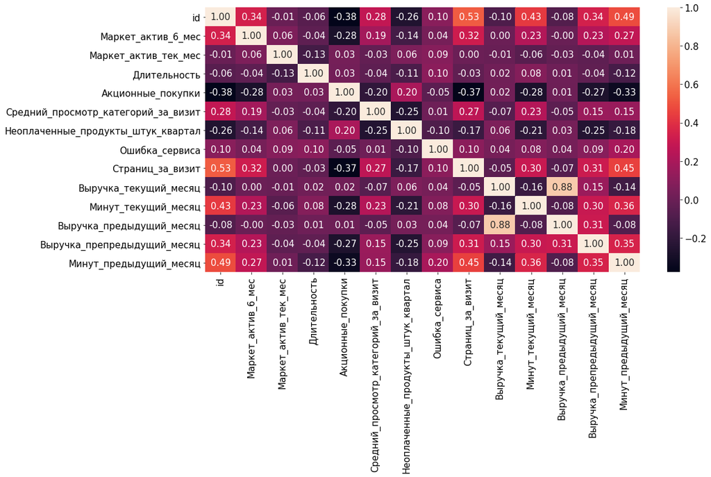

```python
fig, ax = plt.subplots(figsize=(16,8))
sns.heatmap(market.corr(method='spearman'), annot=True, fmt='.2f', ax=ax);
```

- Присутствует как положительная так и отрицательная взаимосвязь между признаками.
- Сильная положительная взаимосвязь наблюдается между признаками: 'Выручка_предыдущий_месяц' и 'Выручка_текущий_месяц'.
- Умененная полжительная взаимосвязь наблюдается между признаками: 'Страниц_за_визит' и 'Минут_предыдущий_месяц'.

### Посмотрим распредление покупательской активности в зависимости от показателей

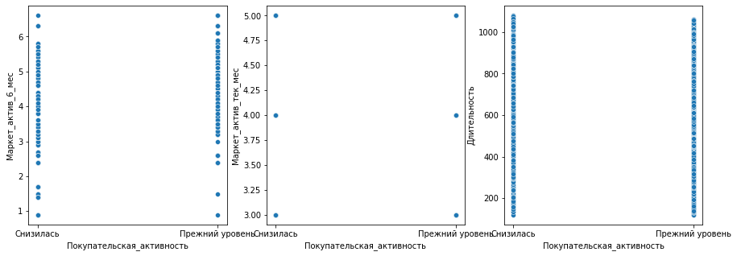

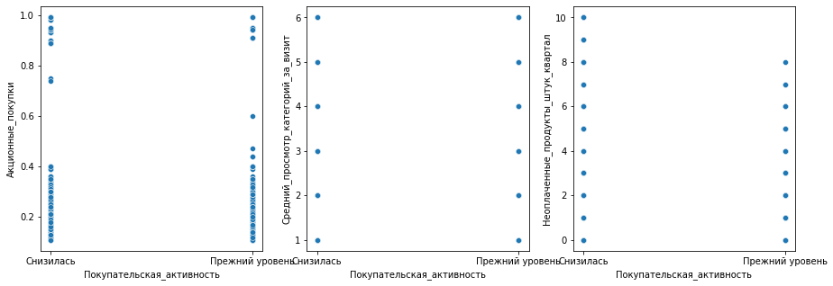

```python
plt.rcParams.update({'font.size': 10})
fig, axes=plt.subplots(nrows=1,ncols=3, figsize=(15,5))
sns.scatterplot(x=market['Покупательская_активность'], y=market['Маркет_актив_6_мес'], ax=axes[0])
axes[0].set_xlabel('Покупательская_активность')
axes[0].set_ylabel('Маркет_актив_6_мес')

sns.scatterplot(x=market['Покупательская_активность'], y=market['Маркет_актив_тек_мес'], ax=axes[1])
axes[1].set_xlabel('Покупательская_активность')
axes[1].set_ylabel('Маркет_актив_тек_мес')

sns.scatterplot(x=market['Покупательская_активность'], y=market['Длительность'], ax=axes[2])
axes[2].set_xlabel('Покупательская_активность')
axes[2].set_ylabel('Длительность')

fig, axes=plt.subplots(nrows=1,ncols=3, figsize=(15,5))
sns.scatterplot(x=market['Покупательская_активность'], y=market['Акционные_покупки'], ax=axes[0])
axes[0].set_xlabel('Покупательская_активность')
axes[0].set_ylabel('Акционные_покупки')

sns.scatterplot(x=market['Покупательская_активность'], y=market['Средний_просмотр_категорий_за_визит'], ax=axes[1])
axes[1].set_xlabel('Покупательская_активность')
axes[1].set_ylabel('Средний_просмотр_категорий_за_визит')

sns.scatterplot(x=market['Покупательская_активность'], y=market['Неоплаченные_продукты_штук_квартал'], ax=axes[2])
axes[2].set_xlabel('Покупательская_активность')
axes[2].set_ylabel('Неоплаченные_продукты_штук_квартал')

plt.show()
```

- Наблюдается равномерное распредление покупательской активности в зависимости от признаков: 'Маркет_актив_тек_мес', 'Длительность', 'Средний_просмотр_категорий_за_визит'.
- Признаки 'Маркет_актив_6_мес', 'Акционные_покупки', 'Неоплаченные_продукты_штук_квартал' распределенны не равномерно по покупательской активности. Можно сказать, что среднемесячное значение маркетинговых коммуникаций компании, которое приходилось на покупателя за последние 6 месяцев выше у класса покупательской активности «прежний уровень». Общее число неоплаченных товаров в корзине за последние 3 месяца чаще больше наблюдается у класса покупательской активности «снизилась».

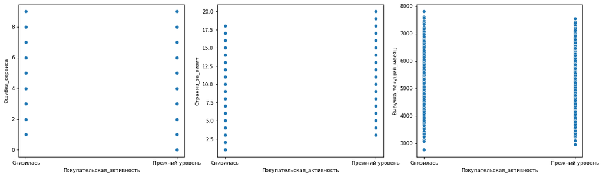

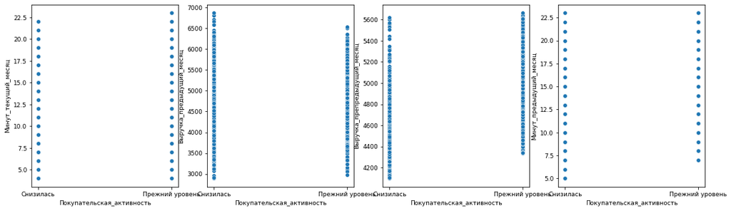

```python
plt.rcParams.update({'font.size': 9})
fig, axes=plt.subplots(nrows=1,ncols=3, figsize=(18,5))
sns.scatterplot(x=market['Покупательская_активность'], y=market['Ошибка_сервиса'], ax=axes[0])
axes[0].set_xlabel('Покупательская_активность')
axes[0].set_ylabel('Ошибка_сервиса')

sns.scatterplot(x=market['Покупательская_активность'], y=market['Страниц_за_визит'], ax=axes[1])
axes[1].set_xlabel('Покупательская_активность')
axes[1].set_ylabel('Страниц_за_визит')

sns.scatterplot(x=market['Покупательская_активность'], y=market['Выручка_текущий_месяц'], ax=axes[2])
axes[2].set_xlabel('Покупательская_активность')
axes[2].set_ylabel('Выручка_текущий_месяц')

fig, axes=plt.subplots(nrows=1,ncols=4, figsize=(18,5))
sns.scatterplot(x=market['Покупательская_активность'], y=market['Минут_текущий_месяц'], ax=axes[0])
axes[0].set_xlabel('Покупательская_активность')
axes[0].set_ylabel('Минут_текущий_месяц')

sns.scatterplot(x=market['Покупательская_активность'], y=market['Выручка_предыдущий_месяц'], ax=axes[1])
axes[1].set_xlabel('Покупательская_активность')
axes[1].set_ylabel('Выручка_предыдущий_месяц')

sns.scatterplot(x=market['Покупательская_активность'], y=market['Выручка_препредыдущий_месяц'], ax=axes[2])
axes[2].set_xlabel('Покупательская_активность')
axes[2].set_ylabel('Выручка_препредыдущий_месяц')

sns.scatterplot(x=market['Покупательская_активность'], y=market['Минут_предыдущий_месяц'], ax=axes[3])
axes[3].set_xlabel('Покупательская_активность')
axes[3].set_ylabel('Минут_предыдущий_месяц')

plt.show()
```

- Наблюдается равномерное распредление покупательской активности в зависимости от признаков: 'Ошибка_сервиса', 'Выручка_текущий_месяц', 'Минут_текущий_месяц'.
- Признаки 'Страниц_за_визит', 'Минут_предыдущий_месяц', 'Выручка_предыдущий_месяц', 'Выручка_препредыдущий_месяц' распределенны не равномерно по покупательской активности.

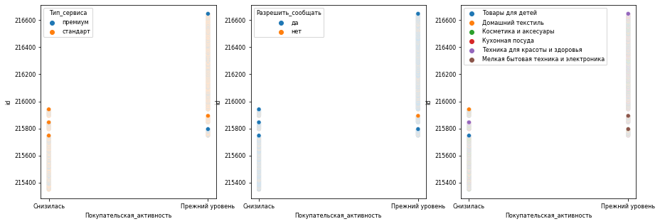

```python
plt.rcParams.update({'font.size': 8})
fig, axes=plt.subplots(nrows=1,ncols=3, figsize=(15,5))

sns.scatterplot(x=market['Покупательская_активность'], y=market['id'], hue=market['Тип_сервиса'], ax=axes[0])
axes[0].set_xlabel('Покупательская_активность')
axes[0].set_ylabel('id')

sns.scatterplot(x=market['Покупательская_активность'], y=market['id'], hue=market['Разрешить_сообщать'], ax=axes[1])
axes[1].set_xlabel('Покупательская_активность')
axes[1].set_ylabel('id')

sns.scatterplot(x=market['Покупательская_активность'], y=market['id'], hue=market['Популярная_категория'], ax=axes[2])
axes[2].set_xlabel('Покупательская_активность')
axes[2].set_ylabel('id')

plt.legend(loc=2)
plt.show()
```

- Класс покупательской активности «снизилась» больше выбирает тип сервиса «стандарт», в то время как у класса «прежний уровень» также большая часть покупателей выбирает «стандарт», но и присутствует тип сервиса «премиум».
- Класс покупательской активности «снизилась» больше разрешает присылать покупателю дополнительные предложения о товаре, в то время как у класса «прежний уровень» также большая часть покупателей также разрешает присылать предложения, но и присутствуют такие покупатели, которые не разрешают.
- Класс покупательской активности «снизилась» больше предпочитает следующие категории товаров: "Домашний текстиль", "Техника для красоты и здоровья", "Товары для детей", в то время как у класса «прежний уровень» покупатели предпочитают категории товаров следующие: "Техника для красоты и здоровья", "Кухонная посуда" и "Мелкая бытовая техника и электроника".

### Выводы по корреляционному анализу данных

**По матрице коэффициентов корреляции, можно сказать следующее:**

- Присутствует как положительная так и отрицательная взаимосвязь между признаками.
- Сильная положительная взаимосвязь наблюдается между признаками: 'Выручка_предыдущий_месяц' и 'Выручка_текущий_месяц'.
- Умененная полжительная взаимосвязь наблюдается между признаками: 'Страниц_за_визит' и 'Минут_предыдущий_месяц'.

**По графикам распредления покупательской активности в зависимости от показателей можно сделать следующие выводы:**

- Наблюдается равномерное распредление покупательской активности в зависимости от признаков: 'Маркет_актив_тек_мес', 'Длительность', 'Средний_просмотр_категорий_за_визит'.
- Признаки 'Маркет_актив_6_мес', 'Акционные_покупки', 'Неоплаченные_продукты_штук_квартал' распределенны не равномерно по покупательской активности. Можно сказать, что среднемесячное значение маркетинговых коммуникаций компании, которое приходилось на покупателя за последние 6 месяцев выше у класса покупательской активности «прежний уровень». Общее число неоплаченных товаров в корзине за последние 3 месяца чаще больше наблюдается у класса покупательской активности «снизилась».
- Наблюдается равномерное распредление покупательской активности в зависимости от признаков: 'Ошибка_сервиса', 'Выручка_текущий_месяц', 'Минут_текущий_месяц'.
- Признаки 'Страниц_за_визит', 'Минут_предыдущий_месяц', 'Выручка_предыдущий_месяц', 'Выручка_препредыдущий_месяц' распределенны не равномерно по покупательской активности.
- Класс покупательской активности «снизилась» больше выбирает тип сервиса «стандарт», в то время как у класса «прежний уровень» также большая часть покупателей выбирает «стандарт», но и присутствует тип сервиса «премиум».
- Класс покупательской активности «снизилась» больше разрешает присылать покупателю дополнительные предложения о товаре, в то время как у класса «прежний уровень» также большая часть покупателей также разрешает присылать предложения, но и присутствуют такие покупатели, которые не разрешают.
- Класс покупательской активности «снизилась» больше предпочитает следующие категории товаров: "Домашний текстиль", "Техника для красоты и здоровья", "Товары для детей", в то время как у класса «прежний уровень» покупатели предпочитают категории товаров следующие: "Техника для красоты и здоровья", "Кухонная посуда" и "Мелкая бытовая техника и электроника".

## Использование пайплайнов

На данном шаге необходимо использовать для обучения лучшей модели. Для этого требуется:

- Во время подготовки данных использовать `ColumnTransformer`. Количественные и категориальные признаки обработать в пайплайне раздельно. Для кодирования категориальных признаков использовать как минимум два кодировщика, для масштабирования количественных — как минимум два скейлера.
- Обучить четыре модели: `KNeighborsClassifier()`, `DecisionTreeClassifier()`, `LogisticRegression()` и `SVC()`. Для каждой из них подобрать как минимум один гиперпараметр. Выбрать подходящую для задачи метрику, аргументировать свой выбор. Использовать эту метрику при подборе гиперпараметров.
- Выбрать лучшую модель, используя заданную метрику. Для этого применить одну из стратегий:
  - использовать пайплайны и инструменты подбора гиперпараметров для каждой модели отдельно, чтобы выбрать лучшую модель самостоятельно;
  - использовать один общий пайплайн для всех моделей и инструмент подбора гиперпараметров, который вернёт вам лучшую модель.

Для нашей задачи - предсказать класс покупательской активности, подойдет метрика accuracy, которая определяет, насколько точно модель предсказывает результаты на основе данных, то есть либо «снизилась», либо «прежний уровень».

```python
market.head(5)
```

|  | id | Покупательская_активность | Тип_сервиса | Разрешить_сообщать | Маркет_актив_6_мес | Маркет_актив_тек_мес | Длительность | Акционные_покупки | Популярная_категория | Средний_просмотр_категорий_за_визит | Неоплаченные_продукты_штук_квартал | Ошибка_сервиса | Страниц_за_визит | Выручка_текущий_месяц | Минут_текущий_месяц | Выручка_предыдущий_месяц | Выручка_препредыдущий_месяц | Минут_предыдущий_месяц |
| --- | --- | --- | --- | --- | --- | --- | --- | --- | --- | --- | --- | --- | --- | --- | --- | --- | --- | --- |
| 1 | 215349 | Снизилась | премиум | да | 4.4 | 4 | 819 | 0.75 | Товары для детей | 4 | 4 | 2 | 5 | 4971.6 | 10.0 | 5216.0 | 4472.0 | 12.0 |
| 2 | 215350 | Снизилась | стандарт | нет | 4.9 | 3 | 539 | 0.14 | Домашний текстиль | 5 | 2 | 1 | 5 | 5058.4 | 13.0 | 5457.5 | 4826.0 | 8.0 |
| 3 | 215351 | Снизилась | стандарт | да | 3.2 | 5 | 896 | 0.99 | Товары для детей | 5 | 0 | 6 | 4 | 6610.4 | 13.0 | 6158.0 | 4793.0 | 11.0 |
| 4 | 215352 | Снизилась | стандарт | нет | 5.1 | 3 | 1064 | 0.94 | Товары для детей | 3 | 2 | 3 | 2 | 5872.5 | 11.0 | 5807.5 | 4594.0 | 8.0 |
| 5 | 215353 | Снизилась | стандарт | да | 3.3 | 4 | 762 | 0.26 | Домашний текстиль | 4 | 1 | 1 | 4 | 5388.5 | 10.0 | 4738.5 | 5124.0 | 10.0 |

### Создадим общий пайплайн для подготовки данных

```python
market['Покупательская_активность'] = market['Покупательская_активность'].apply(lambda x: 0 if x == 'Снизилась' else (1 if x == 'Прежний уровень' else x))

# загружаем данные
X_train, X_test, y_train, y_test = train_test_split(
    market.drop(['Покупательская_активность', 'id'], axis=1),
    market['Покупательская_активность'],
    test_size = TEST_SIZE,
    random_state = RANDOM_STATE,
    stratify = market['Покупательская_активность'])

# создаём списки с названиями признаков
ohe_columns = ['Популярная_категория']
ord_columns = ['Тип_сервиса', 'Разрешить_сообщать']
num_columns = ['Маркет_актив_6_мес', 'Длительность',
               'Маркет_актив_тек_мес',
               'Средний_просмотр_категорий_за_визит',
               'Неоплаченные_продукты_штук_квартал',
               'Ошибка_сервиса', 'Страниц_за_визит',
               'Акционные_покупки',
               'Выручка_текущий_месяц',
               'Минут_текущий_месяц',
               'Выручка_предыдущий_месяц',
               'Выручка_препредыдущий_месяц',
               'Минут_предыдущий_месяц']

# создаём пайплайн для подготовки признаков из списка ohe_columns: заполнение пропусков и OHE-кодирование
# SimpleImputer + OHE
ohe_pipe = Pipeline(
    [('simpleImputer_ohe', SimpleImputer(missing_values=np.nan, strategy='most_frequent')),
     ('ohe', OneHotEncoder(drop='first', handle_unknown='error', sparse_output=False))])

# создаём пайплайн для подготовки признаков из списка ord_columns: заполнение пропусков и Ordinal-кодирование
# SimpleImputer + OE
ord_pipe = Pipeline(
    [('simpleImputer_before_ord', SimpleImputer(missing_values=np.nan, strategy='most_frequent')),
     ('ord',  OrdinalEncoder(
                categories=[
                    ['премиум', 'стандарт'],
                    ['да', 'нет'],],
                handle_unknown='use_encoded_value', unknown_value=np.nan)),
     ('simpleImputer_after_ord', SimpleImputer(missing_values=np.nan, strategy='most_frequent'))])

# создаём общий пайплайн для подготовки данных
data_preprocessor = ColumnTransformer(
    [('ohe', ohe_pipe, ohe_columns),
     ('ord', ord_pipe, ord_columns),
     ('num', StandardScaler(), num_columns)
    ],
    remainder='passthrough')
```

### Создадим итоговый пайплайн

```python
# создаём итоговый пайплайн: подготовка данных и модель
pipe_final = Pipeline([
    ('preprocessor', data_preprocessor),
    ('models', DecisionTreeClassifier(random_state=RANDOM_STATE))])

param_grid = [
    {'models': [DecisionTreeClassifier(random_state=RANDOM_STATE)],
     'models__max_depth': range(2,5),
     'models__max_features': range(2,5),
     'preprocessor__num': [StandardScaler(), MinMaxScaler(), 'passthrough']},

    {'models': [KNeighborsClassifier()],
     'models__n_neighbors': range(2,5),
     'preprocessor__num': [StandardScaler(), MinMaxScaler(), 'passthrough']},

    {'models': [LogisticRegression(
        random_state=RANDOM_STATE,
        solver='liblinear',
        penalty='l1')],
     'models__C': range(1,4),
     'preprocessor__num': [StandardScaler(), MinMaxScaler(), 'passthrough']},

    {'models': [SVC(random_state=RANDOM_STATE, probability=True)],
     'models__C':[0.1,1,10],
     'models__kernel':['linear'],
     'models__degree':[2,3, 4],
     'models__gamma':[1,0.1,10],
     'preprocessor__num': [StandardScaler(), MinMaxScaler(), 'passthrough']}]
```

### Найдем лучшую модель и ее параметры

```python
randomized_search = RandomizedSearchCV(
    pipe_final,
    param_grid,
    scoring='accuracy',
    random_state=RANDOM_STATE,
    n_jobs=-1,
    error_score='raise')
randomized_search.fit(X_train, y_train)

print('Лучшая модель и её параметры:\n\n', randomized_search.best_estimator_)
```

```
Лучшая модель и её параметры:

 Pipeline(steps=[('preprocessor',
                 ColumnTransformer(remainder='passthrough',
                                   transformers=[('ohe',
                                                  Pipeline(steps=[('simpleImputer_ohe',
                                                                   SimpleImputer(strategy='most_frequent')),
                                                                  ('ohe',
                                                                   OneHotEncoder(drop='first',
                                                                                 sparse_output=False))]),
                                                  ['Популярная_категория']),
                                                 ('ord',
                                                  Pipeline(steps=[('simpleImputer_before_ord',
                                                                   SimpleImputer(strategy='most_frequent')),
                                                                  (...
                                                   'Средний_просмотр_категорий_за_визит',
                                                   'Неоплаченные_продукты_штук_квартал',
                                                   'Ошибка_сервиса',
                                                   'Страниц_за_визит',
                                                   'Акционные_покупки',
                                                   'Выручка_текущий_месяц',
                                                   'Минут_текущий_месяц',
                                                   'Выручка_предыдущий_месяц',
                                                   'Выручка_препредыдущий_месяц',
                                                   'Минут_предыдущий_месяц'])])),
                ('models',
                 SVC(C=0.1, degree=4, gamma=0.1, kernel='linear',
                     probability=True, random_state=42))])
```

### Вывод по получившейся модели с помощью пайплайна:

- Лучшая модель - SVC с гиперпараметрами C=0.1, kernel='linear', degree=4, gamma=0.1, random_state=42

## Анализ важности признаков

На данном этапе необходимо сделать следующее:

1. Оценить важность признаков для лучшей модели и построть график важности с помощью метода SHAP.
2. Сделать выводы о значимости признаков:
   - какие признаки мало значимы для модели;
   - какие признаки сильнее всего влияют на целевой признак;
   - как можно использовать эти наблюдения при моделировании и принятии бизнес-решений.

### Оценим важность признаков для лучшей модели и построим график важности с помощью метода SHAP

```python
X_train_e = pipe_final.named_steps['preprocessor'].fit_transform(X_train)
explainer = shap.Explainer(randomized_search.best_estimator_.named_steps['models'], X_train_e)
X_test_e = pipe_final.named_steps['preprocessor'].transform(X_test)

X_test_e = pd.DataFrame(X_test_e, columns = pipe_final.named_steps['preprocessor'].get_feature_names_out())
shap_values = explainer(X_test_e)
```

Построим столбчатую диаграмму `shap.plots.bar`, которая отражает общий вклад признаков в прогнозы модели. Она показывает средние SHAP-значения признака по всем наблюдениям.

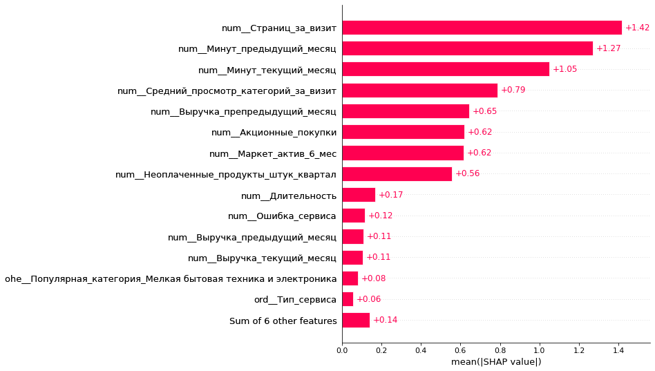

```python
shap.plots.bar(shap_values, max_display=15)
```

### Выводы о значимости признаков:

Исходя из столбчатой диаграммы, можно сделать следующий выводы:

- Признаки "Тип_сервиса" и "Популярная_категория" мало значимы для модели;
- Признаки "Страница_за_визит" и "Минут_предыдущий_месяц" сильнее всего влияют на целевой признак;
- Данные наблюдения можно использовать как важный критерий при определении покупательской активности. То есть, если покупательская активность зависит от среднего количества страниц, которые просмотрел покупатель за один визит и времени, которое покупатель провел на сайте, то для увеличения активности необходимо сделать упор на дизайн сайта, а также продумать структуру сайта, чтобы она была удобной будущим и нынешним покупателям и понятной поисковым роботам.

## Сегментация покупателей

На данном шаге необходимо выполнить следующие задачи:

1. Выполнить сегментацию покупателей. Использовать результаты моделирования и данные о прибыльности покупателей.
2. Выбрать группу покупателей и предложить, как увеличить её покупательскую активность:
   - Провести графическое и аналитическое исследование группы покупателей.
   - Сделать предложения по работе с сегментом для увеличения покупательской активности.
3. Сделать выводы о сегментах:
   - какой сегмент взяли для дополнительного исследования,
   - какие предложения сделали и почему.

### Выполним сегментацию покупателей

```python
y_test_pred = randomized_search.predict(X_test)
#print(y_test_pred)
```

```python
y_test_pred_prob = randomized_search.predict_proba(X_test)[:,1]
#print(y_test_pred_prob)
```

|  | id | Прибыль | Вероятность_снижения |
| --- | --- | --- | --- |
| 0 | 215348 | 0.98 | 0.194104 |
| 1 | 215349 | 4.16 | 0.862300 |
| 2 | 215350 | 3.13 | 0.861283 |
| 3 | 215351 | 4.87 | 0.966362 |
| 4 | 215352 | 4.21 | 0.651911 |

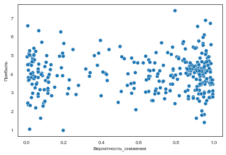

```python
sns.set_style('white')
y_test_pred_prob = pd.Series(y_test_pred_prob, name='Вероятность_снижения')
money_pred_prob = pd.concat([money, y_test_pred_prob], axis=1)
display(money_pred_prob.head())
a = sns.scatterplot(data = money_pred_prob, x = 'Вероятность_снижения', y = 'Прибыль')
```